# desilike

### Cobaya

```python
%%file _tests/config_bao_fs.yaml

theory:
  classy:
    extra_args:
      N_ncdm: 1
      N_ur: 2.0328

likelihood:
  cobaya_bindings.bao_likelihood.BAOLikelihood:
      python_path: _tests
  cobaya_bindings.fs_likelihood.FSLikelihood:
      python_path: _tests

params:
  Omega_m:
    prior:
      min: 0.1
      max: 1.
    ref:
      dist: norm
      loc: 0.3
      scale: 0.01
    latex: \Omega_{m}
  omega_b: 0.02237
  H0: 67.36
  As: 2.083e-09
  n_s: 0.9649
  tau_reio: 0.0544

sampler:
  mcmc:
    Rminus1_stop: 0.05

debug: False

output: _tests/chains_bao_fs_cobaya/chain
```

```
Writing _tests/config_bao_fs.yaml
```

Let's sample!

```python
!cobaya-run -f _tests/config_bao_fs.yaml
```

```
/bin/bash: /home/adematti/anaconda3/envs/cosmodesi-main/lib/libtinfo.so.6: no version information available (required by /bin/bash)
[output] Output to be read-from/written-into folder '_tests/chains_bao_fs_cobaya', with prefix 'chain'
[jax._src.xla_bridge] Unable to initialize backend 'cuda': module 'jaxlib.xla_extension' has no attribute 'GpuAllocatorConfig'
[jax._src.xla_bridge] Unable to initialize backend 'rocm': module 'jaxlib.xla_extension' has no attribute 'GpuAllocatorConfig'
[jax._src.xla_bridge] Unable to initialize backend 'tpu': INVALID_ARGUMENT: TpuPlatform is not available.
[jax._src.xla_bridge] *WARNING* No GPU/TPU found, falling back to CPU. (Set TF_CPP_MIN_LOG_LEVEL=0 and rerun for more info.)
[classy] `classy` module loaded successfully from /home/adematti/anaconda3/envs/cosmodesi-main/lib/python3.10/site-packages/classy-3.2.0-py3.10-linux-x86_64.egg
[BAOCompressionObservable] Found quantities ['qpar', 'qper'].
[BAOCompressionObservable] Found quantities ['qiso'].
[Emulator] Loading _tests/emulator.npy.
[mcmc] Getting initial point... (this may take a few seconds)
[Differentiation] Varied parameters: ['sn0'].
[Differentiation] Varied parameters: ['sn0'].
[model] Measuring speeds... (this may take a few seconds)
[model] Setting measured speeds (per sec): {cobaya_bindings.bao_likelihood.BAOLikelihood: 306.0, cobaya_bindings.fs_likelihood.FSLikelihood: 30.8, classy: 13.1}
[mcmc] Initial point: Omega_m:0.3073328, b1:1.091012
[mcmc] Covariance matrix not present. We will start learning the covariance of the proposal earlier: R-1 = 30 (would be 2 if all params loaded).
[mcmc] Sampling!
[mcmc] Progress @ 2023-08-29 18:07:15 : 1 steps taken, and 0 accepted.
[mcmc] Learn + convergence test @ 80 samples accepted.
[mcmc]  - Acceptance rate: 0.218
[mcmc]  - Convergence of means: R-1 = 22.185724 after 64 accepted steps
[mcmc]  - Updated covariance matrix of proposal pdf.
[mcmc] Learn + convergence test @ 160 samples accepted.
[mcmc]  - Acceptance rate: 0.328
[mcmc]  - Convergence of means: R-1 = 2.803663 after 128 accepted steps
[mcmc]  - Updated covariance matrix of proposal pdf.
[mcmc] Learn + convergence test @ 240 samples accepted.
[mcmc]  - Acceptance rate: 0.347
[mcmc]  - Convergence of means: R-1 = 1.136052 after 192 accepted steps
[mcmc]  - Updated covariance matrix of proposal pdf.
[mcmc] Progress @ 2023-08-29 18:08:15 : 813 steps taken, and 253 accepted.
[mcmc] Learn + convergence test @ 320 samples accepted.
[mcmc]  - Acceptance rate: 0.384
[mcmc]  - Convergence of means: R-1 = 0.290871 after 256 accepted steps
[mcmc]  - Updated covariance matrix of proposal pdf.
[mcmc] Learn + convergence test @ 400 samples accepted.
[mcmc]  - Acceptance rate: 0.407
[mcmc]  - Convergence of means: R-1 = 0.091241 after 320 accepted steps
[mcmc]  - Updated covariance matrix of proposal pdf.
[mcmc] Learn + convergence test @ 480 samples accepted.
[mcmc]  - Acceptance rate: 0.402
[mcmc]  - Convergence of means: R-1 = 0.048005 after 384 accepted steps
[mcmc]  - Updated covariance matrix of proposal pdf.
[mcmc] Learn + convergence test @ 560 samples accepted.
[mcmc]  - Acceptance rate: 0.405
[mcmc]  - Convergence of means: R-1 = 0.032636 after 448 accepted steps
[mcmc]  - Convergence of bounds: R-1 = 0.214897 after 560 accepted steps
[mcmc]  - Updated covariance matrix of proposal pdf.
[mcmc] Progress @ 2023-08-29 18:09:15 : 1619 steps taken, and 592 accepted.
[mcmc] Learn + convergence test @ 640 samples accepted.
[mcmc]  - Acceptance rate: 0.403
[mcmc]  - Convergence of means: R-1 = 0.049529 after 512 accepted steps
[mcmc]  - Convergence of bounds: R-1 = 0.202402 after 640 accepted steps
[mcmc]  - Updated covariance matrix of proposal pdf.
[mcmc] Learn + convergence test @ 720 samples accepted.
[mcmc]  - Acceptance rate: 0.412
[mcmc]  - Convergence of means: R-1 = 0.041538 after 576 accepted steps
[mcmc]  - Convergence of bounds: R-1 = 0.124077 after 720 accepted steps
[mcmc] The run has converged!
[mcmc] Sampling complete after 720 accepted steps.
```

### CosmoSIS

```python
%%file _tests/config_bao_fs.ini

[DEFAULT]
fatal_errors = T

[runtime]
sampler = emcee

[output]
filename = _tests/chains_bao_fs_cosmosis/chain.txt
format = text
verbosity = 0

[pipeline]
modules = consistency camb bao fs
values = _tests/values_bao_fs.ini
likelihoods = BAOLikelihood FSLikelihood  ; notice the name of the likelihood: the same as the *.py file
quiet = T
debug = F
timing = F

[bao]
file = _tests/cosmosis_bindings/BAOLikelihood.py

[fs]
file = _tests/cosmosis_bindings/FSLikelihood.py

[consistency]
file = ${COSMOSIS_STD_DIR}/utility/consistency/consistency_interface.py

[camb]
file = ${COSMOSIS_STD_DIR}/boltzmann/camb/camb_interface.py
mode = background
feedback = 0
; We need quite fine redshift spacing, because the supernovae
; go down to low z where things are pretty sensitive
nz = 901

[class]
file = ${COSMOSIS_STD_DIR}/boltzmann/class/class_interface.py
mpk = False
lensing = False
cmb = False

[cosmoprimo]
file = /home/adematti/Bureau/DESI/NERSC/cosmodesi/cosmoprimo/cosmoprimo/bindings/cosmosis/cosmoprimo_interface.py
engine = class

[emcee]
walkers = 9
samples = 800
nsteps = 20

[test]
fatal_errors = T
```

```
Writing _tests/config_bao_fs.ini
```

In this case the likelihood has nuisance parameters, to be copied in the input `*values.ini` file.

```python
!cat _tests/cosmosis_bindings/FSLikelihood_values.ini
```

```
/bin/bash: /home/adematti/anaconda3/envs/cosmodesi-main/lib/libtinfo.so.6: no version information available (required by /bin/bash)
[desi]
sigmapar = 0.0
sigmaper = 0.0
b1 = 0.0 1.5 4.0
```

```python
%%file _tests/values_bao_fs.ini

[desi]
sigmapar = 0.0
sigmaper = 0.0
b1 = 0.0 1.5 4.0

[cosmological_parameters]
; This is the only parameter being varied.
omega_m = 0.1 0.3 0.9
ombh2 = 0.02237
h0 = 0.6736
A_s = 2.083e-09
n_s = 0.9649
tau = 0.0544

mnu = 0.06
nnu = 3.046
num_massive_neutrinos = 1
omega_k = 0.0
w = -1.0
wa = 0.0
```

```
Writing _tests/values_bao_fs.ini
```

Let's sample!

```python
!cosmosis _tests/config_bao_fs.ini
```

```
/bin/bash: /home/adematti/anaconda3/envs/cosmodesi-main/lib/libtinfo.so.6: no version information available (required by /bin/bash)
Deprecated: The [pipeline] quiet option is deprecated.  Set [runtime] verbosity instead.
Setting up pipeline from parameter file _tests/config_bao_fs.ini
----------------------------------------------------------------
No GPU/TPU found, falling back to CPU. (Set TF_CPP_MIN_LOG_LEVEL=0 and rerun for more info.)

Setting up module consistency
------------------------------

Setting up module camb
-----------------------

Setting up module bao
----------------------

Setting up module fs
---------------------
Setup all pipeline modules


Parameter Priors
----------------
desi--sigmapar                                  ~ delta(0.0)
desi--sigmaper                                  ~ delta(0.0)
desi--b1                                        ~ U(0.0, 4.0)
cosmological_parameters--omega_m                ~ U(0.1, 0.9)
cosmological_parameters--ombh2                  ~ delta(0.02237)
cosmological_parameters--h0                     ~ delta(0.6736)
cosmological_parameters--a_s                    ~ delta(2.083e-09)
cosmological_parameters--n_s                    ~ delta(0.9649)
cosmological_parameters--tau                    ~ delta(0.0544)
cosmological_parameters--mnu                    ~ delta(0.06)
cosmological_parameters--nnu                    ~ delta(3.046)
cosmological_parameters--num_massive_neutrinos  ~ delta(1)
cosmological_parameters--omega_k                ~ delta(0.0)
cosmological_parameters--w                      ~ delta(-1.0)
cosmological_parameters--wa                     ~ delta(0.0)

* Running sampler 1/1: emcee
* Running in serial mode.
```

[output cut: 30 more lines]

```
Done 560 iterations of emcee. Acceptance fraction 0.684
Done 580 iterations of emcee. Acceptance fraction 0.683
Done 600 iterations of emcee. Acceptance fraction 0.686
Done 620 iterations of emcee. Acceptance fraction 0.687
Done 640 iterations of emcee. Acceptance fraction 0.688
Done 660 iterations of emcee. Acceptance fraction 0.687
Done 680 iterations of emcee. Acceptance fraction 0.687
Done 700 iterations of emcee. Acceptance fraction 0.685
Done 720 iterations of emcee. Acceptance fraction 0.687
Done 740 iterations of emcee. Acceptance fraction 0.689
Done 760 iterations of emcee. Acceptance fraction 0.689
Done 780 iterations of emcee. Acceptance fraction 0.689
Done 800 iterations of emcee. Acceptance fraction 0.691
Total posterior evaluations = 7209 across all processes
Successful posterior evaluations = 7209 across all processes
```

### MontePython

```python
!ls -la _tests/montepython_bindings/FSLikelihood
!cp -r _tests/montepython_bindings/FSLikelihood _tests/montepython_public/montepython/likelihoods/
```

```
/bin/bash: /home/adematti/anaconda3/envs/cosmodesi-main/lib/libtinfo.so.6: no version information available (required by /bin/bash)
total 20
drwxr-xr-x 2 adematti idphp 4096 août  29 18:06 .
drwxr-xr-x 4 adematti idphp 4096 août  29 18:06 ..
-rw-r--r-- 1 adematti idphp   33 août  29 18:07 FSLikelihood.data
-rw-r--r-- 1 adematti idphp  268 août  29 18:07 FSLikelihood.param
-rw-r--r-- 1 adematti idphp  477 août  29 18:07 __init__.py
/bin/bash: /home/adematti/anaconda3/envs/cosmodesi-main/lib/libtinfo.so.6: no version information available (required by /bin/bash)
```

In this case the likelihood has nuisance parameters, to be copied in the input `*.param` file.

```python
!cat _tests/montepython_bindings/FSLikelihood/FSLikelihood.param
```

```
/bin/bash: /home/adematti/anaconda3/envs/cosmodesi-main/lib/libtinfo.so.6: no version information available (required by /bin/bash)
# To be copy-pasted in the MontePython *.param file
data.parameters['sigmapar'] = [0.0, 0.0, 10.0, 0.0, 1.0, 'nuisance']
data.parameters['sigmaper'] = [0.0, 0.0, 10.0, 0.0, 1.0, 'nuisance']
data.parameters['b1'] = [1.5, 0.0, 4.0, 0.28867513459481287, 1.0, 'nuisance']
```

```python
%%file _tests/conf_bao_fs.param

data.experiments = ['BAOLikelihood', 'FSLikelihood']

# Cosmological parameters list
data.parameters['Omega_m'] = [0.3, 0.1, 0.9, 0.1, 1., 'cosmo']
# Fixed parameters
data.parameters['omega_b'] = [0.02237, 0.001, 0.1, 0., 1., 'cosmo']
data.parameters['H0'] = [67.36, 0.1, 0.9, 0., 1., 'cosmo']
data.parameters['A_s'] = [2.083e-09, 1e-09, 3e-09, 0., 1., 'cosmo']
data.parameters['n_s'] = [0.9649, 0.9, 1.0, 0., 1., 'cosmo']
data.parameters['tau_reio'] = [0.0544, 0.02, 0.1, 0., 1., 'cosmo']

# Nuisance parameters list
data.parameters['sigmapar'] = [0.0, 0.0, 10.0, 0.0, 1.0, 'nuisance']
data.parameters['sigmaper'] = [0.0, 0.0, 10.0, 0.0, 1.0, 'nuisance']
data.parameters['b1'] = [1.5, 0.0, 4.0, 0.28867513459481287, 1.0, 'nuisance']

# Cosmo arguments
data.cosmo_arguments['k_pivot'] = 0.05
# The base model features two massless
# and one massive neutrino with m=0.06eV.
# The settings below ensures that Neff=3.046
# and m/omega = 93.14 eV
data.cosmo_arguments['N_ur'] = 2.0328
data.cosmo_arguments['N_ncdm'] = 1
data.cosmo_arguments['m_ncdm'] = 0.06
data.cosmo_arguments['T_ncdm'] = 0.71611

#------ MCMC parameters ----
# Number of steps taken, by default (overwritten by the -N command)
data.N = 12000
# Number of accepted steps before writing to file the chain. Larger means less
# access to disc, but this is not so much time consuming.
data.write_step = 5
```

```
Writing _tests/conf_bao_fs.param
```

Let's sample!

```python
!python _tests/montepython_public/montepython/MontePython.py run --conf _tests/montepython_public/default.conf -p _tests/conf_bao_fs.param -o _tests/chains_bao_fs_montepython
```

```
/bin/bash: /home/adematti/anaconda3/envs/cosmodesi-main/lib/libtinfo.so.6: no version information available (required by /bin/bash)
 /!\ PyMultiNest detected but MultiNest likely not installed correctly. You can
     safely ignore this if not running with option -m NS
Running Monte Python v3.6.0

with CLASS v3.2.0

Testing likelihoods for:
 ->BAOLikelihood, FSLikelihood

No GPU/TPU found, falling back to CPU. (Set TF_CPP_MIN_LOG_LEVEL=0 and rerun for more info.)
Creating _tests/chains_bao_fs_montepython/2023-08-29_12000__1.txt


Deduced starting covariance matrix:
```

[output cut: 7315 more lines]

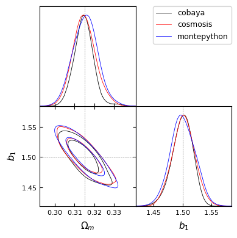

```python
g = plots.get_subplot_plotter()
g.triangle_plot([samples_bao_fs_cobaya, samples_bao_fs_cosmosis, samples_bao_fs_montepython],
                 params=['Omega_m', 'b1'], markers={'Omega_m': cosmo['Omega_m'], 'b1': 1.5})
```

# Wrap-up

- compressed or full-shape likelihoods are defined only once, within desilike
- bindings for Cobaya, CosmoSIS and MontePython are generated with a simple function call
- for Cobaya, the generated likelihood can be straightforwardly imported
- for CosmoSIS and MontePython, the description of nuisance parameters need be copied into the input config files